# Xinyu wang’s Resume

## 个人情况

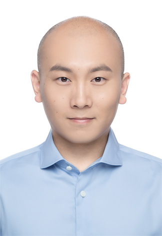

| 性别：男 | 年龄：26岁 |
| --- | --- |
| 籍贯：河北 唐山 | 电话：18602996480 |
| 邮箱：xinyugrey@163.com |  |
| 个人爱好：Iot,羽毛球，篮球以及各种精细的事务 |  |

## 教育背景

| **2017.09-2020.06** | **西安交通大学** | **硕士** |
| --- | --- | --- |

**专业**：医学部共公卫生（卫生管理与政策） **学位**：公共卫生专业硕士

| **2012.09-2017.06** | **南方医科大学** | **本科** |
| --- | --- | --- |

**专业**：预防医学（食品安全） **学位**：医学学士

## 荣誉奖励

| **2017.09至今** | **校级二等学业奖学金、校级专硕奖学金** |
| --- | --- |
| **2014.06** | **广州国际龙舟邀请赛（大学生组）第四名** |

## 科研项目经历

| **2019.06-2019.09** | **陕西省县级公立医院经济运行分析** | **项目负责人** |
| --- | --- | --- |

**工作内容**：收集陕西**165**家全部县级公立医院经济运行相关数据（数据量**2**万余）；使用**R**建立数据库，并对数据进行清晰、分析；使用**Rmarkdown**撰写研究报告（**3**万余字）。

**项目成果**：形成《陕西省县级公立医院经济运行分析报告》，为陕西省实施取消耗材加成政策提供了依据。

| **2018.06-2018.12** | **2017年陕西省卫生总费用研究** | **项目负责人** |
| --- | --- | --- |

**工作内容**：组织并培训**500+**人会议**4**次；使用**Stata**建立数据库（数据量**300+**万），并对数据进行审核、清洗和统计分析；撰写研究报告（**3**万余字）并在全国年会做成果汇报。

**项目成果**：在整体上对陕西省卫生资金筹集、分配、使用到人群受益的全部流动过程进行了核算，从宏观上了解了陕西省卫生费用的筹资来源与机构流向，从微观上分析了卫生费用在不同医疗机构之间的功能流向、人群年龄分布、疾病分布等。并通过进一步细化核算口径，增加核算维度，提高了数据的国内及国际间可比性，更大程度满足了日益增长的政策分析需要，为分析卫生筹资过程中存在的问题，制定和调整卫生筹资政策提供支持。

| **2018.02-2018.06** | **西安市采供血机构布局规划研究** | **主要负责人** |
| --- | --- | --- |

**工作内容**：使用**Stata**构建项目分析所需数据库（数据量**20+**万）；在西安市**9**区**4**县做实地考察，并撰写考察报告；对郑州、武汉、成都**3**个城市血站做实地考察。

**项目成果**：充分了考虑西安市主城区的实际情况及未来城市新区的发展变化，合理布局了采血点，既要考虑了当前临床血液的需求，又要适当考虑到了前瞻性。在充分提高了资源利用效率、优化资源结构的同时，也要保障了制定资源配置标准时的供需平衡，为西安市血站采血点布局提供了依据。

## 社会活动经历

| **2017.09.24-27** | **“一带一路”全球健康国际研讨会** | **参加全英文研究报告5场** |
| --- | --- | --- |
| **2018.03.25** | **2017-2018中国大学生马拉松联赛** | **参与并跑完2公里** |
| **2018.09-2018.12** | **《医学统计学》助教** | **代课2节、批改作业5次** |
| **2019.05.24-26** | **“一带一路”全球健康国际研讨会** | **作为志愿者协助办会** |

## 工作技能

**语言技能**：英语**CET4/6**，具有良好的听说读写能力，能够流畅阅读英文专业文件及书籍。

**专业技能**：熟练使用**R**、**Epidata**和**Stata**统计分析软件；精通**统计学**和**流行病学**知识；熟练运用**office**办公软。

## 求职意向

**数据分析师**（对医疗相关数据进行数据分析和数据挖掘，参与制作医疗相关科技产品。）